# Tugas Pertemuan 6: Pemodelan ARIMA Data Sunspot

Nabeel Muhammad Diaz | M0401241069

24 September 2026

## Tujuan

Lakukan pemodelan ARIMA pada 100 amatan **Daily Total Sunspot Number** dari Tugas Pertemuan 1. Ikuti tahapan latihan Pertemuan 6: eksplorasi, pemeriksaan kestasioneran, identifikasi dan pendugaan model, diagnostik sisaan, overfitting, serta peramalan.

## Packages dan Data

```r
library(forecast)
library(TSA)
library(tseries)
```

Data dibaca dari file Tugas Pertemuan 1 agar dataset yang sama tidak perlu disalin dua kali.

```r
data <- read.csv("../../Pertemuan 1/Tugas/data/sunspot_bagian2.csv")
stopifnot(nrow(data) == 100, all(c("Tanggal", "Sunspot") %in% names(data)))
sunspot.ts <- ts(data$Sunspot)
n_train <- floor(0.8 * length(sunspot.ts))
train.ts <- ts(sunspot.ts[1:n_train])
test.ts <- ts(sunspot.ts[(n_train + 1):length(sunspot.ts)], start = n_train + 1)
data.frame(Jumlah = length(sunspot.ts),
           Tanggal_awal = data$Tanggal[1], Tanggal_akhir = data$Tanggal[100],
           Data_latih = length(train.ts), Data_uji = length(test.ts))
```

```
##   Jumlah Tanggal_awal Tanggal_akhir Data_latih Data_uji
## 1    100   2025-06-27    2025-10-04         80       20
```

## Eksplorasi Data

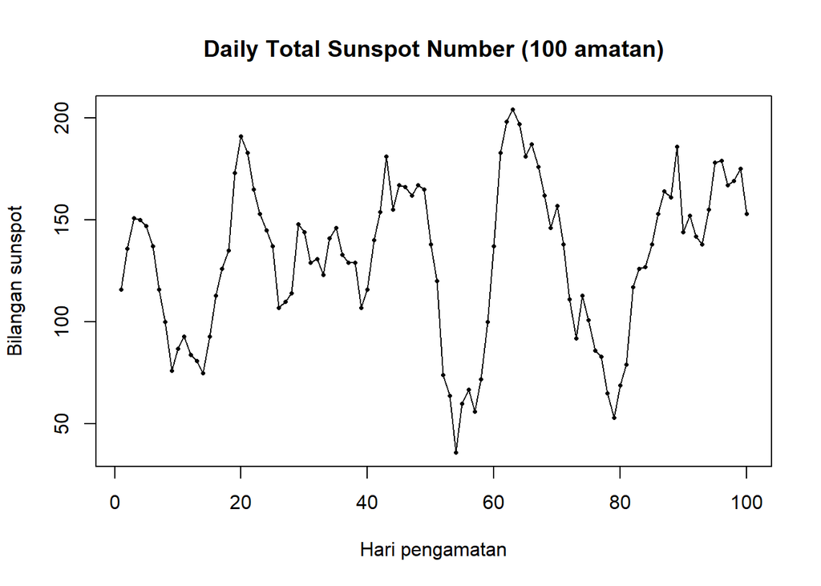

```r
plot(sunspot.ts, type = "o", pch = 16, cex = 0.5,
     xlab = "Hari pengamatan", ylab = "Bilangan sunspot",
     main = "Daily Total Sunspot Number (100 amatan)")
```

```r
summary(sunspot.ts)
```

```
##    Min. 1st Qu.  Median    Mean 3rd Qu.    Max.
##    36.0   107.0   137.5   131.6   161.2   204.0
```

80 amatan pertama menjadi data latih; 20 amatan terakhir disimpan untuk mengukur akurasi ramalan di luar sampel.

## Pemeriksaan Kestasioneran

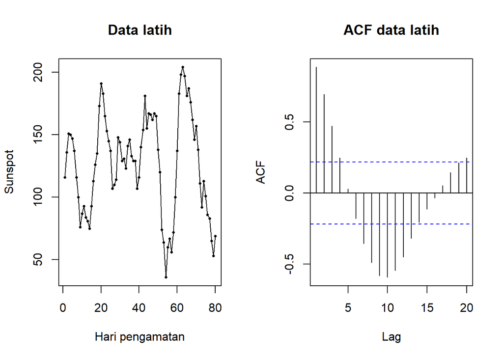

```r
par(mfrow = c(1, 2))
plot(train.ts, type = "o", pch = 16, cex = 0.5,
     xlab = "Hari pengamatan", ylab = "Sunspot", main = "Data latih")
acf(train.ts, lag.max = 20, main = "ACF data latih")
```

```r
par(mfrow = c(1, 1))
tseries::adf.test(train.ts)
```

```
##
##  Augmented Dickey-Fuller Test
##
## data:  train.ts
## Dickey-Fuller = -3.7121, Lag order = 4, p-value = 0.0291
## alternative hypothesis: stationary
```

Hipotesis nol ADF menyatakan data memiliki akar unit. Jika p-value di bawah 0,05, data latih dianggap stasioner dan gunakan `d = 0`; jika tidak, lakukan differencing pertama dan gunakan `d = 1`.

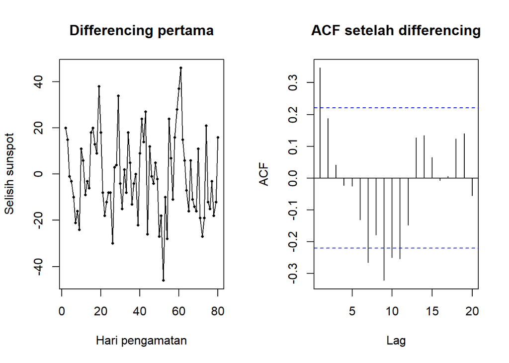

```r
adf_awal <- tseries::adf.test(train.ts)
d <- if (adf_awal$p.value < 0.05) 0L else 1L
train.diff <- diff(train.ts)
par(mfrow = c(1, 2))
plot(train.diff, type = "o", pch = 16, cex = 0.5,
     xlab = "Hari pengamatan", ylab = "Selisih sunspot",
     main = "Differencing pertama")
acf(train.diff, lag.max = 20, main = "ACF setelah differencing")
```

```r
par(mfrow = c(1, 1))
tseries::adf.test(train.diff)
```

```
##
##  Augmented Dickey-Fuller Test
##
## data:  train.diff
## Dickey-Fuller = -3.4377, Lag order = 4, p-value = 0.05555
## alternative hypothesis: stationary
```

## Identifikasi dan Pendugaan Model

Gunakan ACF, PACF, dan EACF dari seri stasioner untuk menyusun kandidat. Orde `d` ditentukan dari uji ADF data latih.

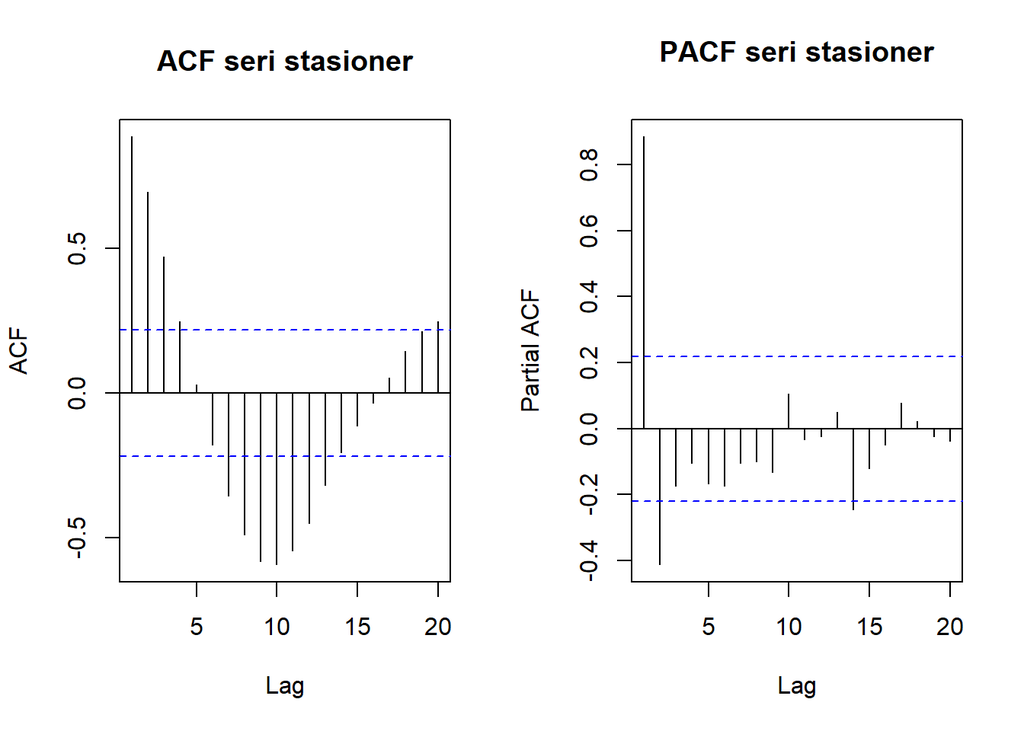

```r
seri.stasioner <- if (d == 0) train.ts else train.diff
par(mfrow = c(1, 2))
acf(seri.stasioner, lag.max = 20, main = "ACF seri stasioner")
pacf(seri.stasioner, lag.max = 20, main = "PACF seri stasioner")
```

```r
par(mfrow = c(1, 1))
TSA::eacf(seri.stasioner)
```

```
## AR/MA
##   0 1 2 3 4 5 6 7 8 9 10 11 12 13
## 0 x x x x o o x x x x x  x  x  o
## 1 x x x x o o x x x x x  o  o  o
## 2 x o o o o o o o o o o  o  o  o
## 3 x o o o o o o o o o o  o  o  o
## 4 x o o o o o o o o o o  o  o  o
## 5 x o x o o o o o o o o  o  o  o
## 6 x o x o o o o o o o o  o  o  o
## 7 o o x o x o o o o o o  o  o  o
```

```r
d
```

```
## [1] 0
```

Bandingkan kandidat dengan AIC. Periksa juga signifikansi parameter dan diagnostik sisaan sebelum menetapkan model.

```r
kandidat <- list(ARIMA_0d0 = c(0,d,0), ARIMA_0d1 = c(0,d,1),
                 ARIMA_1d0 = c(1,d,0), ARIMA_1d1 = c(1,d,1),
                 ARIMA_0d2 = c(0,d,2), ARIMA_2d0 = c(2,d,0))
model <- lapply(kandidat, function(ord)
  forecast::Arima(train.ts, order = ord, method = "ML"))
tabel_model <- data.frame(Model = names(kandidat),
                          AIC = vapply(model, AIC, numeric(1)),
                          BIC = vapply(model, BIC, numeric(1)))
tabel_model <- tabel_model[order(tabel_model$AIC), ]
knitr::kable(tabel_model, digits = 3)
```

|  | Model | AIC | BIC |
| --- | --- | --- | --- |
| ARIMA_2d0 | ARIMA_2d0 | 677.459 | 686.987 |
| ARIMA_1d1 | ARIMA_1d1 | 683.330 | 692.858 |
| ARIMA_1d0 | ARIMA_1d0 | 691.528 | 698.675 |
| ARIMA_0d2 | ARIMA_0d2 | 712.790 | 722.318 |
| ARIMA_0d1 | ARIMA_0d1 | 748.679 | 755.826 |
| ARIMA_0d0 | ARIMA_0d0 | 818.790 | 823.554 |

```r
model_terbaik <- model[[tabel_model$Model[1]]]
summary(model_terbaik)
```

```
## Series: train.ts
## ARIMA(2,0,0) with non-zero mean
##
## Coefficients:
##          ar1      ar2      mean
##       1.2842  -0.4344  124.5525
## s.e.  0.1004   0.1024   11.3428
##
## sigma^2 = 255.5:  log likelihood = -334.73
## AIC=677.46   AICc=677.99   BIC=686.99
##
## Training set error measures:
##                    ME     RMSE      MAE       MPE   MAPE      MASE        ACF1
## Training set 0.151739 15.68116 12.41447 -2.296998 12.096 0.8432875 -0.08506112
```

```r
lmtest::coeftest(model_terbaik)
```

```
##
## z test of coefficients:
##
##            Estimate Std. Error z value  Pr(>|z|)
## ar1         1.28421    0.10035 12.7969 < 2.2e-16 ***
## ar2        -0.43444    0.10236 -4.2443 2.193e-05 ***
## intercept 124.55251   11.34285 10.9807 < 2.2e-16 ***
## ---
## Signif. codes:  0 '***' 0.001 '**' 0.01 '*' 0.05 '.' 0.1 ' ' 1
```

## Diagnostik Sisaan

Periksa normalitas, autokorelasi, dan perubahan ragam sisaan secara visual serta dengan uji formal.

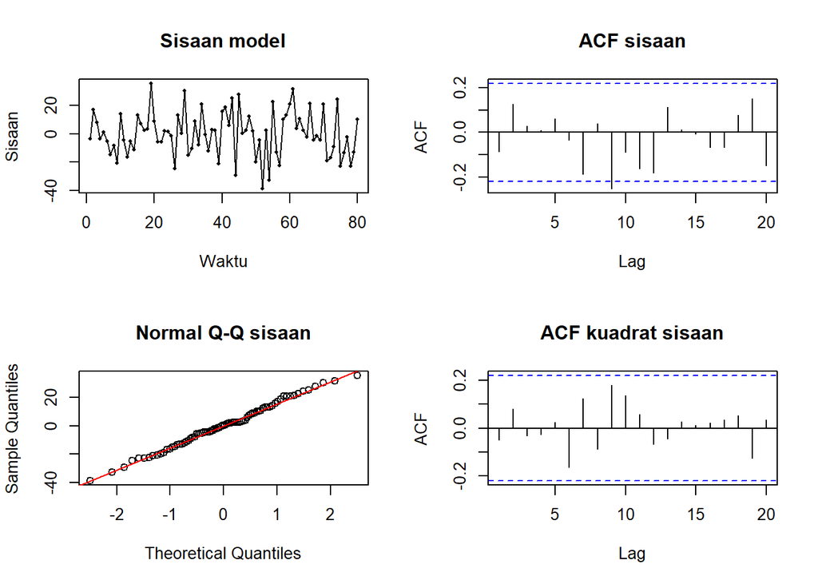

```r
sisaan <- na.omit(residuals(model_terbaik))
par(mfrow = c(2, 2))
plot(sisaan, type = "o", pch = 16, cex = 0.5,
     main = "Sisaan model", xlab = "Waktu", ylab = "Sisaan")
acf(sisaan, lag.max = 20, main = "ACF sisaan")
qqnorm(sisaan, main = "Normal Q-Q sisaan")
qqline(sisaan, col = "red")
acf(sisaan^2, lag.max = 20, main = "ACF kuadrat sisaan")
```

```r
par(mfrow = c(1, 1))
shapiro.test(sisaan)
```

```
##
##  Shapiro-Wilk normality test
##
## data:  sisaan
## W = 0.9928, p-value = 0.9388
```

```r
Box.test(sisaan, lag = 10, type = "Ljung-Box",
         fitdf = length(coef(model_terbaik)))
```

```
##
##  Box-Ljung test
##
## data:  sisaan
## X-squared = 12.411, df = 7, p-value = 0.08784
```

```r
Box.test(sisaan^2, lag = 10, type = "Ljung-Box")
```

```
##
##  Box-Ljung test
##
## data:  sisaan^2
## X-squared = 9.9725, df = 10, p-value = 0.4429
```

## Overfitting

Bandingkan model terpilih dengan model yang orde AR atau MA-nya dinaikkan satu. Pilih model sederhana bila penambahan parameter tidak memperbaiki AIC atau parameternya tidak signifikan.

```r
orde <- arimaorder(model_terbaik)
overfit_orders <- list(
  AR_ditambah = c(orde["p"] + 1, orde["d"], orde["q"]),
  MA_ditambah = c(orde["p"], orde["d"], orde["q"] + 1))
model_overfit <- lapply(overfit_orders, function(ord)
  forecast::Arima(train.ts, order = as.integer(ord), method = "ML"))
perbandingan <- data.frame(
  Model = c("Model terpilih", names(model_overfit)),
  AIC = c(AIC(model_terbaik), vapply(model_overfit, AIC, numeric(1))),
  BIC = c(BIC(model_terbaik), vapply(model_overfit, BIC, numeric(1))),
  RMSE_uji = c(
    forecast::accuracy(forecast::forecast(model_terbaik, h = length(test.ts)), test.ts)["Test set", "RMSE"],
    vapply(model_overfit, function(m) {
      forecast::accuracy(forecast::forecast(m, h = length(test.ts)), test.ts)["Test set", "RMSE"]
    }, numeric(1))))
knitr::kable(perbandingan, digits = 3)
```

|  | Model | AIC | BIC | RMSE_uji |
| --- | --- | --- | --- | --- |
|  | Model terpilih | 677.459 | 686.987 | 35.104 |
| AR_ditambah | AR_ditambah | 675.563 | 687.473 | 31.758 |
| MA_ditambah | MA_ditambah | 667.728 | 679.638 | 39.503 |

```r
lapply(model_overfit, lmtest::coeftest)
```

```
## $AR_ditambah
##
## z test of coefficients:
##
##            Estimate Std. Error z value Pr(>|z|)
## ar1         1.18993    0.10823 10.9943  < 2e-16 ***
## ar2        -0.15246    0.17271 -0.8827  0.37738
## ar3        -0.22150    0.11059 -2.0030  0.04518 *
## intercept 125.36067    9.19166 13.6385  < 2e-16 ***
## ---
## Signif. codes:  0 '***' 0.001 '**' 0.01 '*' 0.05 '.' 0.1 ' ' 1
##
##
## $MA_ditambah
##
## z test of coefficients:
##
##             Estimate Std. Error z value  Pr(>|z|)
## ar1         1.857838   0.036005  51.599 < 2.2e-16 ***
## ar2        -0.931505   0.036002 -25.874 < 2.2e-16 ***
## ma1        -0.999992   0.044412 -22.516 < 2.2e-16 ***
## intercept 130.287553   0.946004 137.724 < 2.2e-16 ***
## ---
## Signif. codes:  0 '***' 0.001 '**' 0.01 '*' 0.05 '.' 0.1 ' ' 1
```

## Peramalan dan Akurasi

Ramalkan 20 amatan data uji dan hitung ukuran akurasi dengan membandingkan hasil ramalan dengan nilai aktual.

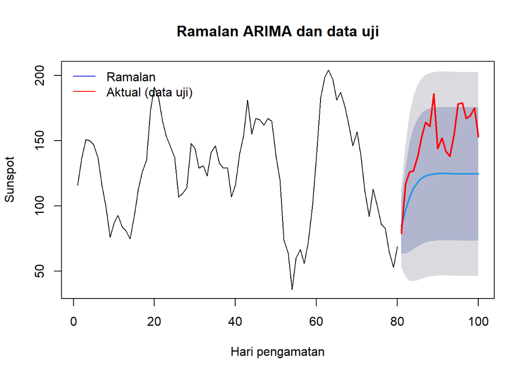

```r
ramalan <- forecast::forecast(model_terbaik, h = length(test.ts))
plot(ramalan, xlab = "Hari pengamatan", ylab = "Sunspot",
     main = "Ramalan ARIMA dan data uji")
lines(test.ts, col = "red", lwd = 2)
legend("topleft", legend = c("Ramalan", "Aktual (data uji)"),
       col = c("blue", "red"), lty = 1, bty = "n")
```

```r
forecast::accuracy(ramalan, test.ts)
```

```
##                     ME     RMSE      MAE       MPE     MAPE      MASE
## Training set  0.151739 15.68116 12.41447 -2.296998 12.09600 0.8432875
## Test set     30.963059 35.10401 31.49274 19.225154 19.89563 2.1392315
##                     ACF1 Theil's U
## Training set -0.08506112        NA
## Test set      0.42123854  1.587548
```

## Kesimpulan

Pada data latih, uji ADF menghasilkan p-value 0,029 sehingga seri dimodelkan tanpa differencing (`d = 0`). Berdasarkan kandidat awal, ARIMA(2,0,0) memiliki AIC terkecil (677,46); kedua koefisien AR signifikan. Uji Shapiro–Wilk (p = 0,939), Ljung–Box pada sisaan (p = 0,088), dan Ljung–Box pada kuadrat sisaan (p = 0,443) tidak menunjukkan pelanggaran diagnostik pada taraf 5%.